# Agendia Interview Quiz

By Jackie Petersen

```python
# imports
import pandas as pd
import numpy as np
import matplotlib.pyplot as plt
import seaborn as sns
```

```python
# reading in the data
df = pd.read_csv('Agendia_dataset.csv')
df.head()
```

|  | Var1 | Var2 | Var3 | Var4 | Var5 | Var6 | Var7 | Var8 | Var9 | Var10 |
| --- | --- | --- | --- | --- | --- | --- | --- | --- | --- | --- |
| 0 | 0.113703 | -0.020142 | -0.191981 | -0.134879 | 0.544054 | -0.109693 | 0.806740 | 0.148723 | 0.236825 | -0.086808 |
| 1 | 0.622299 | 0.775105 | 0.210805 | 0.732455 | 0.681062 | -0.553372 | 0.927581 | 0.598278 | 0.809218 | 0.653693 |
| 2 | 0.609275 | 0.612472 | 0.099767 | 0.468287 | 0.414651 | -0.703363 | 0.453796 | 0.506354 | 0.495636 | 0.007674 |
| 3 | 0.623379 | 0.379336 | 0.380884 | 0.775001 | 0.344287 | -0.603426 | 0.468473 | 0.826142 | 0.770183 | 0.053877 |
| 4 | 0.860915 | 0.863682 | NaN | 0.726049 | 1.089600 | -0.907231 | 0.267629 | 1.149640 | 0.827683 | 0.947081 |

#### Exploring the data

```python
df.info()
```

```
<class 'pandas.core.frame.DataFrame'>
RangeIndex: 50 entries, 0 to 49
Data columns (total 10 columns):
 #   Column  Non-Null Count  Dtype
---  ------  --------------  -----
 0   Var1    50 non-null     float64
 1   Var2    50 non-null     float64
 2   Var3    45 non-null     float64
 3   Var4    50 non-null     float64
 4   Var5    50 non-null     float64
 5   Var6    50 non-null     float64
 6   Var7    50 non-null     float64
 7   Var8    50 non-null     float64
 8   Var9    50 non-null     float64
 9   Var10   50 non-null     float64
dtypes: float64(10)
memory usage: 4.0 KB
```

```python
df.describe()
```

|  | Var1 | Var2 | Var3 | Var4 | Var5 | Var6 | Var7 | Var8 | Var9 | Var10 |
| --- | --- | --- | --- | --- | --- | --- | --- | --- | --- | --- |
| count | 50.000000 | 50.000000 | 45.000000 | 50.000000 | 50.000000 | 50.000000 | 50.000000 | 50.000000 | 50.000000 | 50.000000 |
| mean | 0.469481 | 0.402490 | 0.489891 | 0.535269 | 0.481135 | -0.467637 | 0.495902 | 0.482265 | 0.498750 | 0.502761 |
| std | 0.263871 | 0.318720 | 0.491264 | 0.599893 | 0.360983 | 0.286225 | 0.550506 | 0.359341 | 0.284341 | 0.577238 |
| min | 0.009496 | -0.248381 | -0.409247 | -0.819803 | -0.308535 | -1.069065 | -0.579576 | -0.151533 | -0.051121 | -0.749464 |
| 25% | 0.260404 | 0.225523 | 0.125549 | 0.045341 | 0.244259 | -0.699172 | 0.113581 | 0.199652 | 0.262063 | 0.056919 |
| 50% | 0.493494 | 0.366431 | 0.521477 | 0.607650 | 0.445399 | -0.414533 | 0.446750 | 0.457692 | 0.495754 | 0.416758 |
| 75% | 0.661164 | 0.630165 | 0.815127 | 0.881676 | 0.706706 | -0.222793 | 0.934630 | 0.800995 | 0.718437 | 0.997728 |
| max | 0.992150 | 1.270785 | 1.498083 | 1.660966 | 1.220251 | 0.043707 | 1.697750 | 1.207747 | 1.096372 | 1.807259 |

#### 1. Plot the relationship between the first two columns.

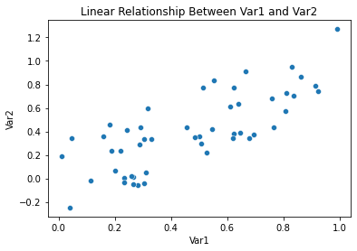

```python
sns.scatterplot(x=df['Var1'], y=df['Var2'])
plt.title('Linear Relationship Between Var1 and Var2');
```

#### 2. What's the Pearson's correlation coefficient between the first two columns?

```python
# getting the correlation coefficients for all the columns
df.corr(method='pearson')
```

|  | Var1 | Var2 | Var3 | Var4 | Var5 | Var6 | Var7 | Var8 | Var9 | Var10 |
| --- | --- | --- | --- | --- | --- | --- | --- | --- | --- | --- |
| Var1 | 1.000000 | 0.765671 | 0.548249 | 0.521885 | 0.748800 | -0.982460 | 0.416261 | 0.891173 | 0.916019 | 0.473801 |
| Var2 | 0.765671 | 1.000000 | 0.421043 | 0.252098 | 0.610176 | -0.798070 | 0.372379 | 0.724134 | 0.692826 | 0.440650 |
| Var3 | 0.548249 | 0.421043 | 1.000000 | 0.442590 | 0.424868 | -0.544264 | 0.265639 | 0.418496 | 0.522285 | 0.344549 |
| Var4 | 0.521885 | 0.252098 | 0.442590 | 1.000000 | 0.325552 | -0.459169 | 0.194794 | 0.382488 | 0.518619 | 0.272015 |
| Var5 | 0.748800 | 0.610176 | 0.424868 | 0.325552 | 1.000000 | -0.743629 | 0.216787 | 0.662832 | 0.760292 | 0.323499 |
| Var6 | -0.982460 | -0.798070 | -0.544264 | -0.459169 | -0.743629 | 1.000000 | -0.427120 | -0.876887 | -0.896611 | -0.463346 |
| Var7 | 0.416261 | 0.372379 | 0.265639 | 0.194794 | 0.216787 | -0.427120 | 1.000000 | 0.322342 | 0.407065 | 0.329266 |
| Var8 | 0.891173 | 0.724134 | 0.418496 | 0.382488 | 0.662832 | -0.876887 | 0.322342 | 1.000000 | 0.794874 | 0.455446 |
| Var9 | 0.916019 | 0.692826 | 0.522285 | 0.518619 | 0.760292 | -0.896611 | 0.407065 | 0.794874 | 1.000000 | 0.415558 |
| Var10 | 0.473801 | 0.440650 | 0.344549 | 0.272015 | 0.323499 | -0.463346 | 0.329266 | 0.455446 | 0.415558 | 1.000000 |

- The Pearson's correlation coefficient for the first two columns (Var1 and Var2) is 0.765671.

#### 3. Between the second and the third?

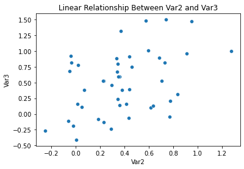

```python
sns.scatterplot(x=df['Var2'], y=df['Var3'])
plt.title('Linear Relationship Between Var2 and Var3');
```

- The Pearson's correlation coefficient between the second and third columns (Var2 and Var3) is 0.421043.

#### 4. Which two columns in the dataset are the most related?

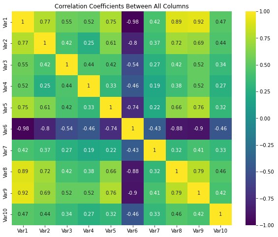

```python
# visualizing the correlation coefficients to interpret easier
plt.figure(figsize=(10,8))
sns.heatmap(df.corr(), annot=True, vmin=-1, cmap='viridis')
plt.title('Correlation Coefficients Between All Columns');
```

- The two most related columns are the 1st and 6th column (Var1 and Var6).

#### 5. How would you show the answer to the previous question visually? Please justify your choice of plot using 1-2 sentences.

- I would create a scatter plot. This plot gives a great visual idea of the linear relationship between the two columns. Since it has the highest correlation, this would give the most linear looking plot. This plot will also show if the relationship is a positive or a negative correlation based on the direction of the line.
- If you wanted to see all the relationships at a glance to see which ones are most related and don't already have that information, then I would create a heatmap like I did above. This just makes it easier to visually see which ones are related by the color at a glance instead of just looking at the raw numbers.

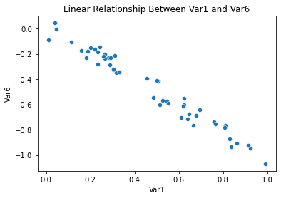

```python
sns.scatterplot(x=df['Var1'], y=df['Var6'])
plt.title('Linear Relationship Between Var1 and Var6');
```

#### 6. What's the equation of the best fit line between the two most related columns?

```python
# Line fitting with numpy polynomial
np.polyfit(df['Var1'], df['Var6'], 1).round(2) # 1 for degree of polynomial - for linear regression
```

```
array([-1.07,  0.03])
```

- The first number in the array above is the slope (a) and the second number is the intercept (b).
- The equation is y = a * x + b. So the equation for this specific problem is:

  > y = -1.07 * x + 0.03

#### 7. Plot the two most related columns and annotate it with the best fit line, its equation, and the Pearson's correlation coefficient.

```python
# Pearson's correlation coefficient for Var1 & Var6
coef = np.corrcoef(x=df['Var1'], y=df['Var6'])[1][0].round(2)
coef
```

```
-0.98
```

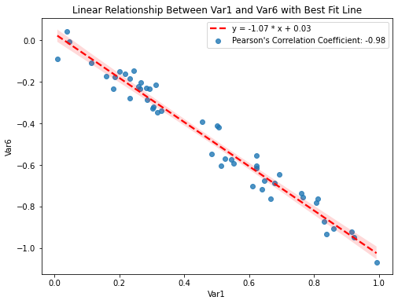

```python
plt.figure(figsize=(8,6))
sns.regplot(data=df, x='Var1', y='Var6', line_kws={'color':'red', 'linestyle':'--'})
plt.title('Linear Relationship Between Var1 and Var6 with Best Fit Line')
plt.legend(labels=["y = -1.07 * x + 0.03", f"Pearson's Correlation Coefficient: {coef}"]);
```